# NFL Pre-Snap Tendencies: static version

The no-install version of the [interactive app](https://github.com/Andresperez397/nfl-presnap-predictability). It has the same data and estimates, as searchable tables. Every rate is shown with its play count. Team rates are shrunk toward the league, cells with fewer than 30 plays are flagged, and seasons run 2019–2025.

## Headline results (held-out tests)

- **Run vs pass from pre-snap information:** on seasons the model never saw, it calls 74.5% of plays correctly (AUC 0.82). Down and distance alone get 62.5%.
- **Team tendencies:** a team’s own earlier-week tendencies, shrunk toward the league, improve week-ahead prediction by 8.2 millinats per play (95% interval 7.3 to 9.0).
- **Stability:** split-half reliability of the team tendency index is r = 0.74. The same offense in consecutive seasons gives r = 0.43.

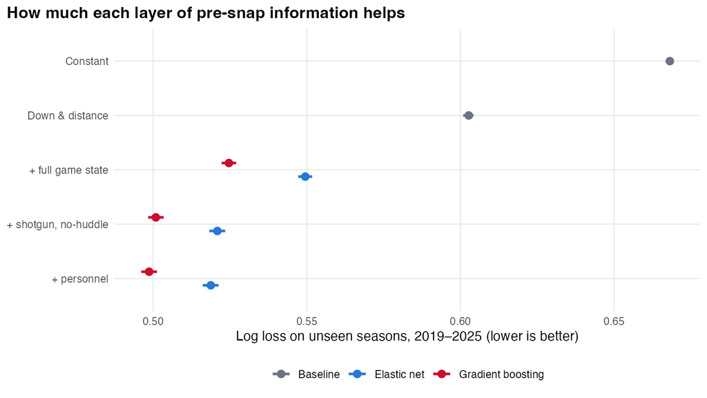

## Tendency index by offense and season

Positive values mean the offense’s own tendencies made it more predictable than league norms. The index is measured on held-out weeks.

| Season | Offense | Index (millinats/play) | 95% interval | Plays |
| --- | --- | --- | --- | --- |
| 2025 | WAS | 25.9 | 14.7 to 37.1 | 907 |
| 2025 | NYJ | 23.2 | 2.0 to 44.4 | 931 |
| 2025 | LA | 23 | 13.8 to 32.1 | 1203 |
| 2025 | ATL | 20.8 | 10.8 to 30.9 | 961 |
| 2025 | NE | 17 | 5.8 to 28.3 | 1192 |
| 2025 | NYG | 15.6 | 2.5 to 28.7 | 1011 |
| 2025 | BAL | 11.3 | 1.5 to 21.2 | 902 |
| 2025 | CHI | 10.3 | 3.1 to 17.5 | 1177 |
| 2025 | MIA | 7.4 | -0.8 to 15.5 | 886 |
| 2025 | JAX | 7.2 | 2.7 to 11.8 | 1063 |

[output cut: 214 more lines]

## Scouting tables

The **league expected** rate is what a league model trained on earlier seasons predicts for the same plays. The **team** rate is the shrunk estimate.

| Season | Offense | View | Group | Plays | Raw | League expected | Team (shrunk) | 95% interval | Flag |
| --- | --- | --- | --- | --- | --- | --- | --- | --- | --- |
| 2025 | ARI | Down &amp; distance | 1st | 459 | 62% | 55% | 61% | 52%–67% |  |
| 2025 | ARI | Down &amp; distance | 2nd 1-3 | 58 | 47% | 39% | 44% | 33%–54% |  |
| 2025 | ARI | Down &amp; distance | 2nd 11+ | 64 | 81% | 81% | 82% | 74%–88% |  |
| 2025 | ARI | Down &amp; distance | 2nd 4-6 | 76 | 72% | 61% | 69% | 58%–77% |  |
| 2025 | ARI | Down &amp; distance | 2nd 7-10 | 160 | 80% | 72% | 78% | 70%–85% |  |
| 2025 | ARI | Down &amp; distance | 3rd 1-3 | 63 | 49% | 54% | 52% | 41%–60% |  |
| 2025 | ARI | Down &amp; distance | 3rd 11+ | 49 | 86% | 89% | 89% | 82%–92% |  |
| 2025 | ARI | Down &amp; distance | 3rd 4-6 | 44 | 93% | 94% | 94% | 89%–97% |  |
| 2025 | ARI | Down &amp; distance | 3rd 7-10 | 67 | 96% | 96% | 96% | 93%–98% |  |
| 2025 | ARI | Down &amp; distance | 4th 1-3 | 13 | 46% | 56% | 56% | 51%–63% | small sample |

[output cut: 4350 more lines]

Data: nflverse play-by-play (CC BY 4.0). Participation comes from NFL Next Gen Stats (through 2022) and FTN Data (2023 on), via nflverse (CC BY-SA 4.0). This page’s data is CC BY-SA 4.0. It is not affiliated with or endorsed by the NFL, nflverse or FTN. Built 2026-10-03.